# Labour force analysis by industry

# Financial and Insurance Services

*Last updated on 2020-09-19.*

A total of 465,963 individuals were employed in Financial and Insurance Services in Feb 2020, before the onset of COVID-19 spread in Australia.

A total of 486,319 individuals were employed in the most recent quarter of May 2020, which is an increase of 4.37 percentage points since Feb 2020.

## Change in employment growth/decline

We can visualise the change in employment for Financial and Insurance Services compared to all other industries as the rate of employment growth or decline since Nov 1984.

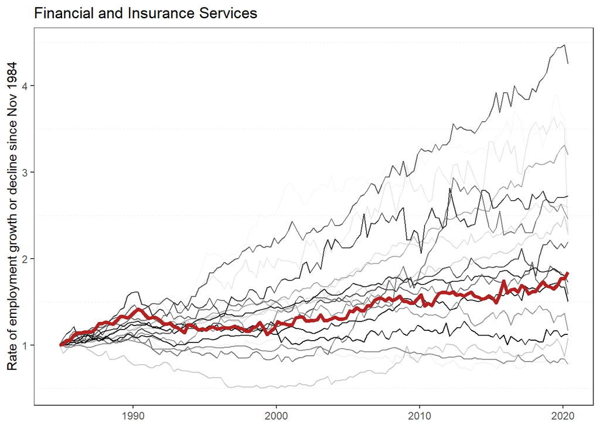

## Number of employed persons over time

We can visualise the total number of employed persons for Financial and Insurance Services since Nov 1984.

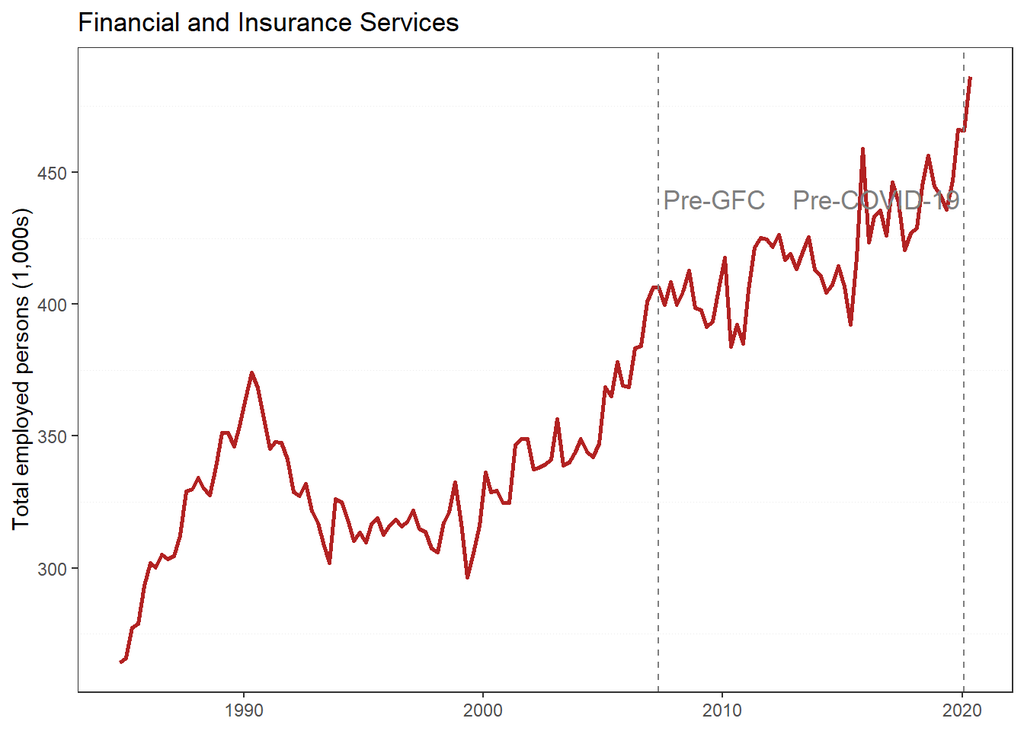

## Changes in total persons employed over time

If we subtract the employed persons count by the preceding quarter’s count, we can visualise the total increase or decrease in employment numbers. This allows us to directly compare how much employment numbers have fluctuated over time between different industries.

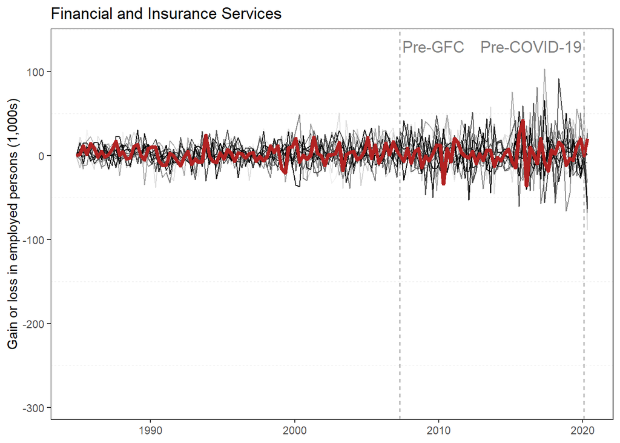

**Note**: The trend for Financial and Insurance Services is highlighted in red.